# semantix-test

## Perguntas

1. Qual profissão tem mais tendência a fazer um empréstimo? De qual tipo?
2. Fazendo uma relação entre número de contatos e sucesso da campanha quais são os pontos relevantes a serem observados?
3. Baseando-se nos resultados de adesão desta campanha qual o número médio e o máximo de ligações que você indica para otimizar a adesão?
4. O resultado da campanha anterior tem relevância na campanha atual?
5. Qual o fator determinante para que o banco exija um seguro de crédito?
6. Quais são as características mais proeminentes de um cliente que possua empréstimo imobiliário?

## Carga dos dados

```r
bank = fread("datasets/bank-full.csv",
             colClasses = c(job='factor', marital='factor', education='factor',
                            default='factor', housing='factor', loan='factor',
                            contact='factor', day='factor', month='factor',
                            poutcome='factor', y='factor'))
```

## Descrição dos dados:

- *age*: idade do cliente (numeric)
- *job* : tipo de emprego (categorical: “admin.”,“unknown”,“unemployed”, “management”, “housemaid”, “entrepreneur”, “student”, “blue-collar”, “self-employed”, “retired”, “technician”, “services”)
- *marital* : estado de relacionamento (casado/solteiro/divorciado) (categorical: “married”, “divorced”, “single”; nota: “divorced” pode ser divorciado(a) ou viúvo(a))
- *education*: nível de educação (categorical: “unknown”, “secondary”, “primary”, “tertiary”)
- *default*: se tem dívidas atrasadas (binary: “yes”, “no”)
- *balance*: saldo anual, em euros (numeric)
- *housing*: se tem empréstimo imobiliário (binary: “yes”, “no”)
- *loan*: se tem empréstimo pessoal (binary: “yes”, “no”)
- *contact*: Meio usado para contato (categorical: “unknown”, “telephone”, “cellular”)
- *day*: Dia do mês do último contato (numeric)
- *month*: Mês do último contato (categorical: “jan”, “feb”, “mar”, …, “nov”, “dec”)
- *duration*: duração do último contato, em segundos (numeric)
- *campaign*: número de contatos feitos nesta campanha para este cliente (numeric, includes last contact)
- *pdays*: número de dias que passaram desde do último contato ao cliente em uma campanha anterior (numeric, -1 significa que não houve contato anterior)
- *previous*: número de contatos feitos antes dessa campanha a este cliente (numeric)
- *poutcome*: resultado deste usuário na ultima campanha de marketing (categorical: “unknown”,“other”,“failure”,“success”)

## Análise geral dos dados:

```r
  summary(bank)
```

```
##       age                 job           marital          education
##  Min.   :18.00   blue-collar:9732   divorced: 5207   primary  : 6851
##  1st Qu.:33.00   management :9458   married :27214   secondary:23202
##  Median :39.00   technician :7597   single  :12790   tertiary :13301
##  Mean   :40.94   admin.     :5171                    unknown  : 1857
##  3rd Qu.:48.00   services   :4154
##  Max.   :95.00   retired    :2264
##                  (Other)    :6835
##  default        balance       housing      loan            contact
##  no :44396   Min.   : -8019   no :20081   no :37967   cellular :29285
##  yes:  815   1st Qu.:    72   yes:25130   yes: 7244   telephone: 2906
##              Median :   448                           unknown  :13020
##              Mean   :  1362
##              3rd Qu.:  1428
##              Max.   :102127
##
##       day            month          duration         campaign
##  20     : 2752   may    :13766   Min.   :   0.0   Min.   : 1.000
##  18     : 2308   jul    : 6895   1st Qu.: 103.0   1st Qu.: 1.000
##  21     : 2026   aug    : 6247   Median : 180.0   Median : 2.000
##  17     : 1939   jun    : 5341   Mean   : 258.2   Mean   : 2.764
##  6      : 1932   nov    : 3970   3rd Qu.: 319.0   3rd Qu.: 3.000
##  5      : 1910   apr    : 2932   Max.   :4918.0   Max.   :63.000
##  (Other):32344   (Other): 6060
##      pdays          previous           poutcome       y
##  Min.   : -1.0   Min.   :  0.0000   failure: 4901   no :39922
##  1st Qu.: -1.0   1st Qu.:  0.0000   other  : 1840   yes: 5289
##  Median : -1.0   Median :  0.0000   success: 1511
##  Mean   : 40.2   Mean   :  0.5803   unknown:36959
##  3rd Qu.: -1.0   3rd Qu.:  0.0000
##  Max.   :871.0   Max.   :275.0000
##
```

Não parece haver muitos outliers ou dados danificados, com a exceção de algumas colunas. Consideramos como outliers, dados aonde há uma grande diferença entre Min e 1º quartil ou Max e 3ºquartil.

## Pergunta 1:

**Qual profissão tem mais tendência a fazer um empréstimo? De qual tipo?**

Antes de iniciar a análise, vamos olhar a frequência de diferentes tipos de profissão nos nossos dados.

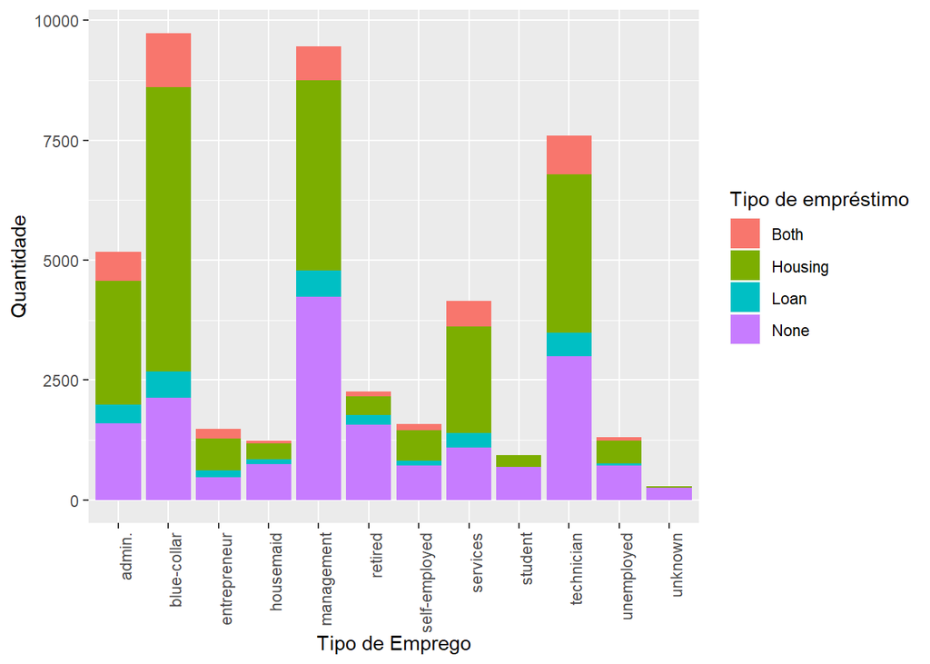

```r
ggplot(bank) + geom_bar(aes(x = job, fill = ifelse(
                                            loan=='yes',
                                            ifelse(housing=='yes','Both','Loan'),
                                            ifelse(housing=='yes','Housing','None'))
                            ), stat = 'count') +
              labs(x='Tipo de Emprego', y='Quantidade', fill='Tipo de empréstimo') +
              theme(axis.text.x = element_text(angle = 90, hjust = 1))
```

Vemos alguns tipos de empregados são bem mais presentes nos dados do que outros, como por exemplo, trabalhadores braçais(blue-collar), gerentes, e técnicos. Também vemos que não podemos inferir efetivamente quais profissões têm mais empréstimos a partir desta vizualização. Contudo, já vemos que empréstimos imobiliários são bem mais frequentes que empréstimos pessoais. Para compensar os problemas listados, iremos olhar as taxas (em porcentagem) de empréstimo pessoal para cada profissão. Essa lógica será repetida em todas as análises desta pergunta.

Para responder a pergunta, relacionaremos a coluna de profissões, com cada uma das colunas relacionadas a empréstimo: loan (empréstimo pessoal), housing(empréstimo habitacional) e uma coluna a ser criada, any_loan, que nos ajudará a descobrir quais profissões pegam empréstimos de qualquer um dos dois tipos.

Realizaremos a análise associando a taxa de empréstimo para cada coluna relacionada a empréstimos com cada uma das profissões listadas em jobs.

#### loan (empréstimo pessoal):

```r
aggregate_ratios <- function(dt, column, by_column){
  percs = dt[, .(.N,
            yes.perc=sum(ifelse(get(column)=='yes',1, 0))*100/.N,
            no.perc=sum(ifelse(get(column)=='no',1, 0))*100/.N
            ), by=.(by.column=get(by_column))]
  return(percs)
}
```

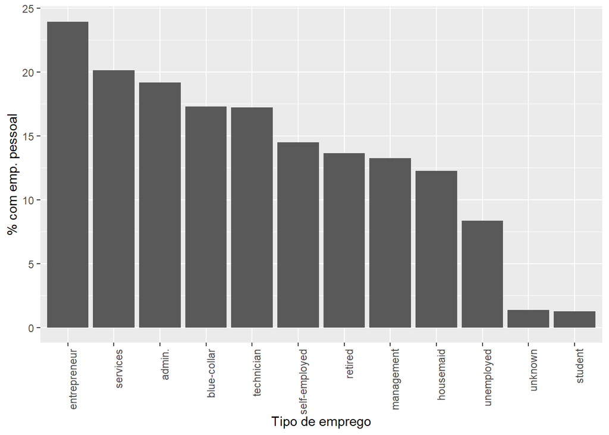

```r
loan_job_ratios = aggregate_ratios(bank, 'loan', 'job')
ggplot(loan_job_ratios) +
    geom_bar(aes(x = reorder(by.column, -yes.perc), y = yes.perc),stat = 'identity') +
    labs(x='Tipo de emprego', y='% com emp. pessoal') +
    theme(axis.text.x = element_text(angle = 90, hjust = 1))
```

Olhando as taxas no gráfico acima, Vemos que empreendedores possuem a maior quantidade de empréstimos pessoais, seguidos por trabalhadores que fornecem serviços, administradores, trabalhadores de fábrica e técnicos.

#### housing (empréstimo imobiliário):

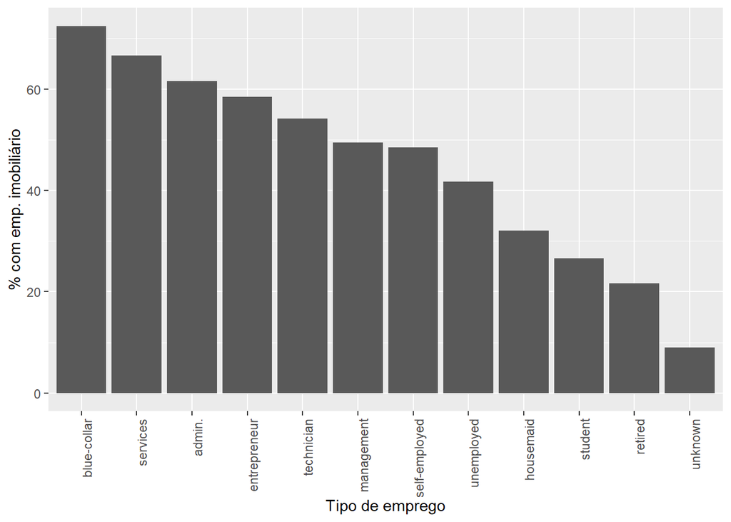

```r
housing_job_ratios = aggregate_ratios(bank, 'housing', 'job')
ggplot(housing_job_ratios) +
    geom_bar(aes(x = reorder(by.column,-yes.perc), y = yes.perc),stat = 'identity') +
    labs(x='Tipo de emprego', y='% com emp. imobiliário') +
    theme(axis.text.x = element_text(angle = 90, hjust = 1))
```

Já para empréstimos imobiliários, fica evidente que a maioria dos clientes (55%) possuem um, com trabalhadores braçais liderando a lista, com mais de 70% destes tendo empréstimo imobiliário pendente. Após estes, vemos trabalhadores de serviços, administradores, empresários e técnicos, todos com mais de 50% de aparição de empréstimos imobiliários.

#### Qualquer Empréstimo

Aqui devemos criar uma coluna para verificar se um usuário fez um tipo qualquer de empréstimo, chamaremos ela de any_loan. Essa coluna terá dois valores: ‘yes’ e ‘no’, que funcionam de maneira similar as outras colunas de empréstimo.

```r
bank$any_loan = ifelse((bank$loan == 'yes') | (bank$housing == 'yes'), 'yes', 'no')
```

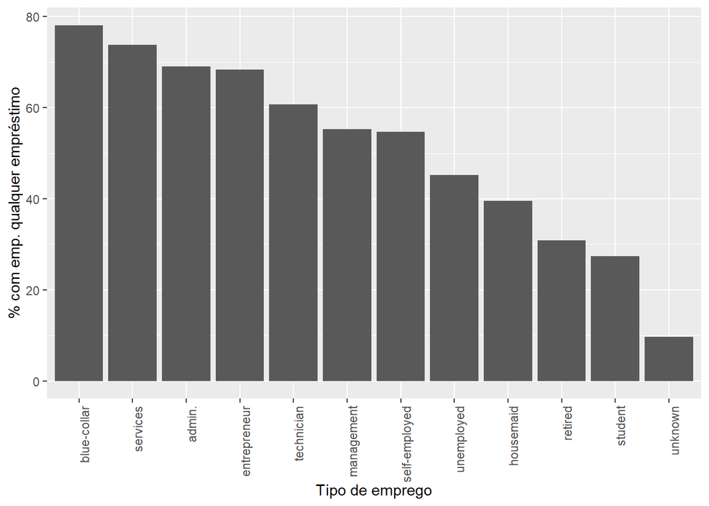

```r
any_loan_job_ratios = aggregate_ratios(bank, 'any_loan', 'job')
ggplot(any_loan_job_ratios) +
    geom_bar(aes(x = reorder(by.column,-yes.perc), y = yes.perc),stat = 'identity') +
    labs(x='Tipo de emprego', y='% com emp. qualquer empréstimo') +
    theme(axis.text.x = element_text(angle = 90, hjust = 1))
```

```r
bank$any_loan = NULL
```

O resultado aqui é bastante similar aos empréstimos imobiliários, o que faz sentido, visto que entre empréstimos pessoais (16% do total) e imobiliários (55% do total) o segundo é bem mais frequente. Assim como nos empréstimos imobiliários, a proissão que mais realiza qualquer tipo de empréstimo é a de trabalhadores braçais, seguidos por trabalhadores de serviços, administradores, empresários e técnicos.

## Pergunta 2:

**Fazendo uma relação entre número de contatos e sucesso da campanha quais são os pontos relevantes a serem observados?**

Similarmente a pergunta anterior, começaremos com uma demonstração dos dados relacionados

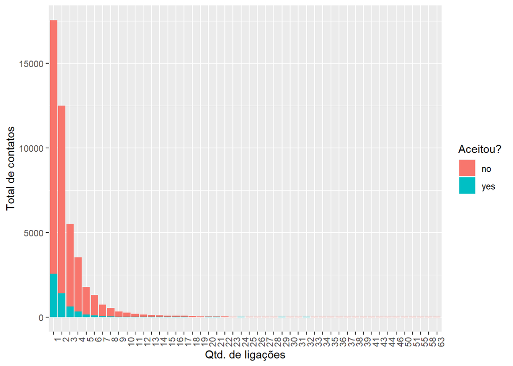

```r
ggplot(bank) + geom_bar(aes(x = factor(campaign), fill = y), stat = 'count') +
             labs(x="Qtd. de ligações", y="Total de contatos", fill="Aceitou?") +
             theme(axis.text.x = element_text(angle = 90, hjust = 1))
```

No gráfico, os clientes são divididos de acordo com a quantidade de ligações recebida. Vemos que há grupos de clientes que foram contatados em grande quantidade. Contudo, estes grupos contêm uma quantidade muito pequena de clientes. Grupos com poucos dados que nem esse, podem não representar a população como um todo e acabam gerando *bias* na análise. Então, para evitar influência destes grupos com poucos usuários na nossa análise, usaremos somente grupos que possuam 100 ou mais usuários.

Para analisar a efetividade da campanha em cada um destes grupos, veremos a taxa de négocios fechados para diferentes quantidades de ligações recebidas. Como resultado, temos o gráfico abaixo.

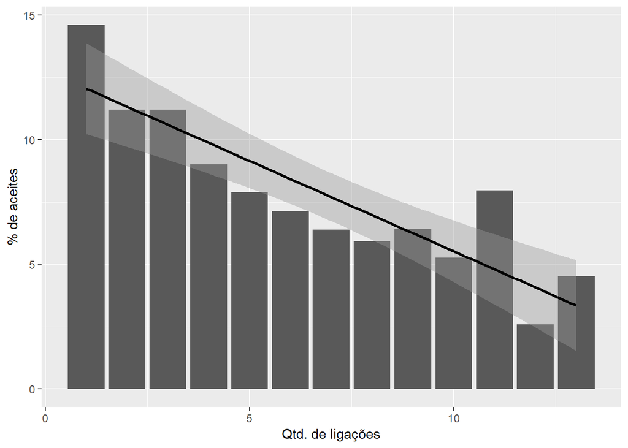

```r
campaign_y_ratios = aggregate_ratios(bank, 'y', 'campaign')
ggplot(campaign_y_ratios[N >= 100], aes(x = by.column, y = yes.perc)) +
    geom_bar(stat = 'identity') +
    geom_smooth(color='black', method='lm') +
    labs(x="Qtd. de ligações", y="% de aceites")
```

No gráfico, vemos que há uma tendência de grupos que recebem menos ligações, fecharem mais contratos. Isso é confirmado pela correlação de pearson entre número de ligações e taxas de aceite, que tem o valor de `-0.7`, indicando que a quantidade de ligações relaciona-se negativamente com a taxa de aceitação do produto.

```r
cor.test(campaign_y_ratios$by.column, campaign_y_ratios$yes.perc)
```

```
##
##  Pearson's product-moment correlation
##
## data:  campaign_y_ratios$by.column and campaign_y_ratios$yes.perc
## t = -6.7964, df = 46, p-value = 1.842e-08
## alternative hypothesis: true correlation is not equal to 0
## 95 percent confidence interval:
##  -0.8258715 -0.5303711
## sample estimates:
##       cor
## -0.707837
```

## Pergunta 3:

**Baseando-se nos resultados de adesão desta campanha qual o número médio e o máximo de ligações que você indica para otimizar a adesão?**

Vendo os dados da pergunta anterior, grupos que recebem mais ligações ainda fecham contratos, apesar de em uma taxa menor do que os que recebem mais. Entretanto, estas ligações poderiam estar sendo utilizadas para ligar para outros potenciais clientes, que teriam mais chance de fechar contrato nas primeiras ligações. Então, a não ser em caso de exaustão de clientes viáveis, é interessante sempre tentar contactar novos clientes, com a média de ligações por cliente devendo ser próxima de 1.

Como vimos acima, é recomendado contactar a maior quantidade de clientes possível, então devemos manter a quantidade média de ligações baixa. Ainda assim, isso nem sempre é algo plasível. Então, para estabelecer uma quantidade máxima de ligações, procuramos uma quantidade de ligações que apresente taxa de aceitação superior a média das taxas de aceitação entre os grupos de usuários analisados.

Para realizar essa análise, construímos o gráfico abaixo. Ele mostra os mesmos dados do gráfico da pergunta anterior, mas agora com os valores do eixo y escaladas em razão da sua distância para a média. O valor 0 no eixo y representa a média, e cada unidade no dito eixo representa um desvio padrão. Vemos que 5 ligações é o último valor para o qual a porcentagem de aceites se mantêm acima da média, com um outro ponto simlar em 11 ligações, mas que devemos considerar como uma exceção, e não parte da regra. Com isso, estabelecemos 5 como um valor razoável para a quantidade máxima de ligações.

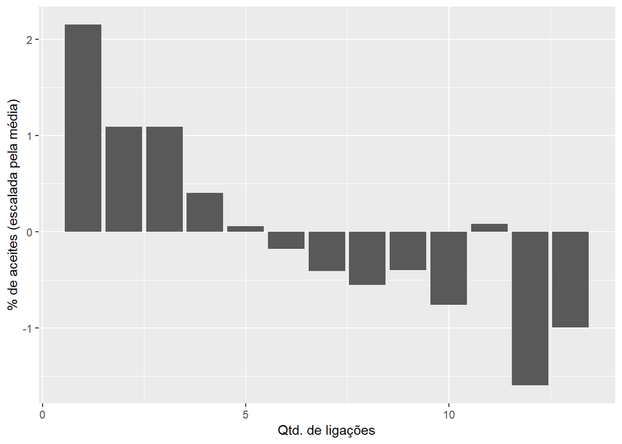

```r
ggplot(campaign_y_ratios[N >= 100], aes(x = by.column, y = scale(yes.perc))) +
    geom_bar(stat = 'identity') +
    labs(x="Qtd. de ligações", y="% de aceites (escalada pela média)")
```

Um detalhamento dos resultados obtidos para todos grupos analisados se encontra na tabela abaixo.

```r
knitr::kable(setorder(campaign_y_ratios[N >= 100,.(campaign = by.column, N, yes.perc, no.perc)], 'campaign'))
```

| campaign | N | yes.perc | no.perc |
| --- | --- | --- | --- |
| 1 | 17544 | 14.597583 | 85.40242 |
| 2 | 12505 | 11.203519 | 88.79648 |
| 3 | 5521 | 11.193624 | 88.80638 |
| 4 | 3522 | 9.000568 | 90.99943 |
| 5 | 1764 | 7.879819 | 92.12018 |
| 6 | 1291 | 7.126259 | 92.87374 |
| 7 | 735 | 6.394558 | 93.60544 |
| 8 | 540 | 5.925926 | 94.07407 |
| 9 | 327 | 6.422018 | 93.57798 |
| 10 | 266 | 5.263158 | 94.73684 |
| 11 | 201 | 7.960199 | 92.03980 |
| 12 | 155 | 2.580645 | 97.41935 |
| 13 | 133 | 4.511278 | 95.48872 |

## Pergunta 4:

**O resultado da campanha anterior tem relevância na campanha atual?**

### Análise numérica

Para respondermos essa pergunta, primeiro precisamos definir o que é relevância. Definieremos que alguma variável relacionada a campanha anterior é relevante se ela impactar de maneira significativa o resultado da campanha atual. Para determinarmos se esse impacto existe, relacionaremos as variáveis associadas a campanha anterior (pdays, previous, poutcome), com o resultado da campanha atual (y).

##### pdays:

Para verificarmos se há relação entre o número de dias desde do último contato e o resultado da campanha atual, compararemos o valor de pdays para resultados positivos e resultados negativos. Levaremos em consideração somente usuários que foram contatados em campanhas anteriores.

A comparação será realizada através de um teste t. Valores de p maiores ou iguais a 0.05 indicam que não há diferença significativa entre os grupos.

```r
t.test(bank[pdays != -1 & y=='yes']$pdays, bank[pdays != -1 & y=='no']$pdays)
```

```
##
##  Welch Two Sample t-test
##
## data:  bank[pdays != -1 & y == "yes"]$pdays and bank[pdays != -1 & y == "no"]$pdays
## t = -13.217, df = 2888.9, p-value < 2.2e-16
## alternative hypothesis: true difference in means is not equal to 0
## 95 percent confidence interval:
##  -47.85138 -35.48793
## sample estimates:
## mean of x mean of y
##  192.5218  234.1914
```

Vemos que há sim uma diferença significativa neste caso. Pessoas que fecharam negócio tendem a ter sido contatadas a menos tempo pelo banco. Entretanto, a quantidade de dias desde do ultimo contato é alta em ambos os casos, com 192 dias para clientes que fecharam negócio vs. 234 dias para clientes que não fecharam, em média.

##### previous:

Aqui aplicaremos a mesma lógica usada em pdays para verificar se a quantidade de ligações recebida tem alguma associação com clientes que fecharam ou não negócio.

```r
t.test(bank[previous > 0 & y=='yes']$previous, bank[previous > 0 & y=='no']$previous)
```

```
##
##  Welch Two Sample t-test
##
## data:  bank[previous > 0 & y == "yes"]$previous and bank[previous > 0 & y == "no"]$previous
## t = 0.94872, df = 4499.6, p-value = 0.3428
## alternative hypothesis: true difference in means is not equal to 0
## 95 percent confidence interval:
##  -0.09953227  0.28619223
## sample estimates:
## mean of x mean of y
##  3.249344  3.156014
```

Neste caso, não aparenta haver diferença significativa entre a quantidade de contatos recebidos em outras campanhas por clientes que fecharam ou não negócio. O que indica que a quantidade de ligações recebidas anteriormente não é um diferencial real neste caso.

##### poutcome:

Como neste caso estamos comparando duas variáveis discretas, não podemos nos utilizar de testes t. Aqui compararemos o resultado da campanha anterior em dois grupos de clientes: os que fecharam negócio nesta campanha ou não. Isso será feito através da diferença da concentração dos valores possíveis de poutcome nos dois grupos.

Aqui usaremos somente os valores ‘failure’ e ‘success’ de poutcome, já que eles são os únicos com uma semântica clara o suficiente para inferirmos resultados, além de indicarem que este usuário já participou de campanhas anteriores.

```r
      sort(
          prop.table(summary(bank[poutcome %in% c("failure", "success") & y=='yes']$poutcome)) -
          prop.table(summary(bank[poutcome %in% c("failure", "success") & y=='no']$poutcome)),
        decreasing = TRUE) * 100
```

```
##   success     other   unknown   failure
##  50.21092   0.00000   0.00000 -50.21092
```

Aqui vemos que usuários que aceitaram a oferta nesta campanha tem muito mais chances de já terem a aceitado anteriormente, com 50% a mais de aceites anteriores por parte destes usuários. Realizaremos este experimento novamente, mas agora na ‘direção oposta’, ou seja, verificando a diferença de aceite atual baseado em aceites anteriores.

```r
      sort(
          prop.table(summary(bank[poutcome=='success']$y)) -
          prop.table(summary(bank[poutcome=='failure']$y)),
        decreasing = TRUE) * 100
```

```
##       yes        no
##  52.11568 -52.11568
```

Assim confirmamos a tendência mostrada no teste anterior. Usuários que já aceitaram uma campanha anterior apresentam 52% a mais de taxa de aceitação na campanha atual, quando comparados com usuários que não aceitaram a última campanha.

### Análise Preditiva

No caso da análise preditiva, consideraremos uma variável relevante, se ela prevê corretamente o resultado da campanha atual. Para tal, construiremos novamente um modelo de Florestas aleatórias para nos permitir a análise do impacto de cada uma das variáveis no resultado.

##### Preprocessamento

Para o random forest funcionar como o esperado, precisamos transformar nossas variáveis categóricas que não são ordernáveis para o formato ‘onehot’. Transformaremos variáveis categóricas que são ordenáveis para inteiros.

```r
rf_bank = copy(bank)
rf_bank$day = as.integer(as.character(rf_bank$day))
rf_bank$month = sapply(rf_bank$month, function(x) grep(paste("(?i)", x, sep=""), month.abb))

oh_encoder = onehot(rf_bank[,1:16], max_levels = 100)

rf_bank = data.table(predict(oh_encoder, rf_bank[,1:16]))
rf_bank$y = bank$y
```

##### Encontrando melhor modelo

Nosso objetivo aqui não é encontrar um modelo viável para realizar previsões. O modelo escolhido poderá sofrer de *overfitting*, mas isso não é o problema, já que nosso objetivo que o modelo descreva nossos dados da forma mais completa possível.

Para aliviar com o fato de que há um forte desbalanço nos nossos alvos de predição (coluna y), balancearemos a importância de cada classe (‘yes’ e ‘no’) pelo inverso da sua frequência. Isso é feito através do atributo `class_weight='balanced'` na inicialização do Random Forest. Para medir as métricas necessárias para comparação entre modelos, usaremos a técnica OOB, específica ao Random Forest.

```r
best_rf <- function(X, y, metric_fun, n_estimators) {
  require(reticulate) #Reticulate is an API that enables the use of python modules on R
  ensemble = import('sklearn.ensemble') #In this case, I'm using scikit-learn.

  oob_results = c()

  for(n_estimator in n_estimators) {
    model = ensemble$RandomForestClassifier(n_estimators=as.integer(n_estimator), class_weight='balanced', oob_score=TRUE)
    model = model$fit(X, as.matrix(y)[, 1])
    oob_decision = data.table(
                      apply(
                        model$oob_decision_function_, 1, FUN=which.max))
    names(oob_decision) = "pred"
    oob_decision$pred = as.integer(oob_decision$pred) == 2 #TRUE == yes, FALSE == no
    oob_decision$real = as.integer(y$y) == 2

    oob_score = metric_fun(oob_decision$real, oob_decision$pred)
    oob_results <- c(oob_results, oob_score)

  }

  oob_results <- setNames(oob_results, n_estimators)
  return(oob_results)
}
```

##### Treinando o melhor modelo:

```r
  rf_feature_importance <- function(X, y, metric_fun, n_estimators){
    ensemble = import('sklearn.ensemble')

    oob_metrics = best_rf(X, y, metric_fun, n_estimators)

    opt_n_estimator = n_estimators[which.max(oob_metrics)]
    model = ensemble$RandomForestClassifier(n_estimators=as.integer(opt_n_estimator),   class_weight='balanced')
    model$fit(X, as.matrix(y)[, 1])
    importances = model$feature_importances_

    importances = data.table(importance = importances,
                           feature = names(X))
    return(importances)
}
```

##### Importância de cada profissão:

```r
  metrics = import('sklearn.metrics')

  importance = rf_feature_importance(X=rf_bank[, 1:40],
                                     y=rf_bank[, 41],
                                     n_estimators=seq.int(from=10, to=100, by=5),
                                     metric_fun=metrics$precision_score)
```

### Resultados

Removemos a feature de duração do resultado da análise preditiva para melhor legibilidade do gráfico. Essa feature apresenta valor algo, e é naturalemente relacionada com o resultado, visto que pessoas que fecham negócio passam mais tempo para dar de conta dos detalhes. Com isso, temos os resultados de importância das features para predição abaixo.

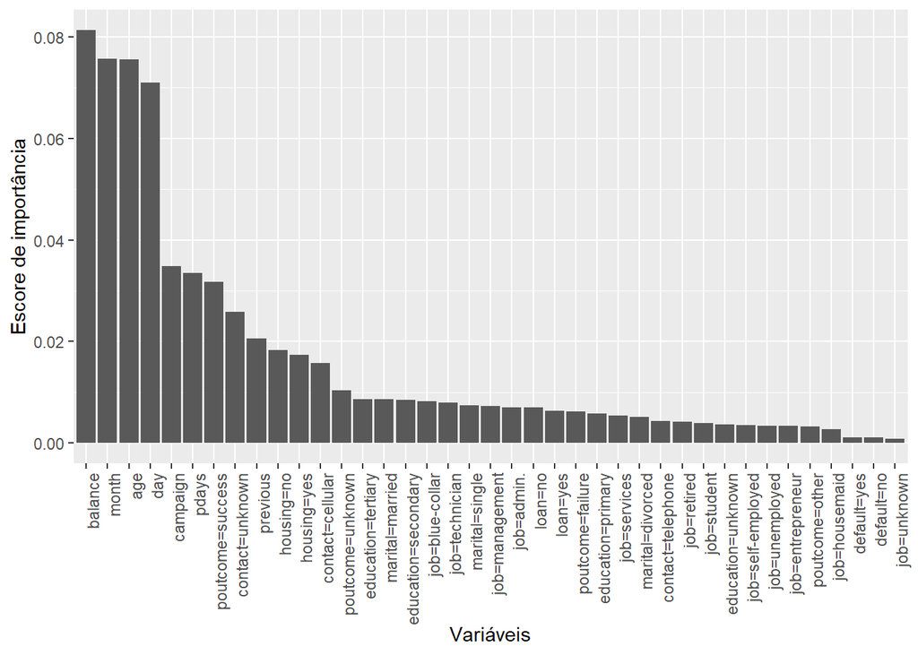

```r
ggplot(importance[feature!='duration']) +
  geom_bar(aes(x=reorder(feature, -importance), y=importance), stat='identity') +
  labs(x='Variáveis', y='Escore de importância') +
  theme(axis.text.x = element_text(angle = 90, hjust = 1))
```

Vemos que os principais fatores que influenciam o usuário são seu saldo atual, sua idade, e a data (mes/dia) do contato. Em uma escala menor, vemos que fatores como: quantidade de contatos (campaign), explorada na Pergunta 3; contatos anteriores em sucedidos (poutcome=sucess), e a quantidade de dias desde do último contato (pdays). Os dois ultimos são relacionados com a nossa pergunta, confirmam o mostrado na análise numérica nos mostrando que, das informações de campanhas anteriores uma *quantidade menor de dias desde do último contato*, e principalmente *o fato de um usuário já ter aceitado a última campanha* são relevantes no resultado da campanha atual.

## Pergunta 5:

**Qual o fator determinante para que o banco exija um seguro de crédito?**

Os dados não especificam para quais clientes o banco exigiu um seguro de crédito. Então temos que definir nos nossos dados o que significa um cliente não ser confiável, e que por consequência precisaria de um seguro de crédito. Poderíamos recomendar, com base no senso comum que clientes com crédito vencido (em *default*), e que possuem saldo bancário negativo não têm condições para confiavelmente pagar seus débitos, e então, necessitariam de seguro de crédito.

Por outro lado, resultados derivados dessa definição não seriam sólidos, já que não temos uma fonte para, pelo menos empiricamente, dar base a essa definição. Então, por medida de segurança e para não incorrer em resultados duvidosos, prefiro levantar que não temos dados o suficiente para resolver essa questão.

## Pergunta 6:

**Quais são as características mais proeminentes de um cliente que possua empréstimo imobiliário?**

Primeiro, temos que dividir nossos usuários em clientes com e sem empréstimo imobiliário. Definiremos as caracteristicas proeminentes dos clientes com emprestimo, a partir da comparação destes com os clientes sem empréstimo

```r
  cli.imo = bank[housing=='yes']
  other.cli = bank[housing=='no']
```

Os dois conjuntos são grandes o suficiente para realizarmos comparações válidas, com 25130 entradas para clientes com empréstimo e 20081 para clientes sem empréstimo. O mínimo necessário para fazermos comparações confiáveis seria de 381 (5% de intervalo de confiança, 95% de nível de confiança), calculado usando o link a seguir: https://www.surveysystem.com/sscalc.htm#one

A partir disso compararemos as variáveis de cada um dos conjuntos, a partir de testes t, no caso de valores continuos, e subtraindo as porcentagens da presença de cada um dos tipos de elementos (com emprestimo - sem emprestímo) no caso de variáveis discretas.

Uma descrição completa dos resultados dos testes encontra-se abaixo.

```r
for(name in names(cli.imo)){
  print(name)
  if(class(cli.imo[,get(name)]) != 'factor'){
    result = t.test(cli.imo[,get(name)], other.cli[,get(name)])
    print(sprintf("t=%.3f, p=%.3f, imo_mean(%s)=%.3f, noimo_mean(%s)=%.3f",
                 result$statistic, result$p.value,
                 name, result$estimate[1],
                 name, result$estimate[2]))
  }else{
    print(
      sort(
        prop.table(summary(cli.imo[,get(name)])) - prop.table(summary(other.cli[,get(name)])), decreasing = TRUE) * 100
      )
  }
  print("")
}
```

```
## [1] "age"
## [1] "t=-38.853, p=0.000, imo_mean(age)=39.175, noimo_mean(age)=43.140"
## [1] ""
## [1] "job"
##   blue-collar      services        admin.  entrepreneur    technician
##    14.6802917     4.0947584     2.7572716     0.3804823    -0.9649231
## self-employed       unknown    unemployed       student     housemaid
##    -1.0094127    -1.2012539    -1.6239081    -2.4402564    -2.6092539
##    management       retired
##    -5.1883945    -6.8754015
## [1] ""
## [1] "marital"
##    married   divorced     single
##  1.7418336  0.1142343 -1.8560679
## [1] ""
## [1] "education"
##  secondary    primary    unknown   tertiary
## 10.2263426  0.7700615 -1.9010532 -9.0953509
## [1] ""
## [1] "default"
##         no        yes
##  0.1613372 -0.1613372
## [1] ""
## [1] "balance"
## [1] "t=-14.081, p=0.000, imo_mean(balance)=1175.103, noimo_mean(balance)=1596.501"
## [1] ""
## [1] "housing"
##  yes   no
##  100 -100
## [1] ""
## [1] "loan"
##       yes        no
##  3.050661 -3.050661
## [1] ""
## [1] "contact"
##    unknown  telephone   cellular
##  18.993258  -3.989198 -15.004060
## [1] ""
## [1] "day"
##          15          13          14          18          17           7
```

[output cut: 25 more lines]

```
## [1] ""
## [1] "pdays"
## [1] "t=27.724, p=0.000, imo_mean(pdays)=51.312, noimo_mean(pdays)=26.289"
## [1] ""
## [1] "previous"
## [1] "t=8.299, p=0.000, imo_mean(previous)=0.657, noimo_mean(previous)=0.485"
## [1] ""
## [1] "poutcome"
##   failure     other   success   unknown
##  6.682058  1.579118 -3.304771 -4.956405
## [1] ""
## [1] "y"
##        no       yes
##  9.002395 -9.002395
## [1] ""
```